# Tutorial 3 Centrality Measures and Metrics with Python

1. Degree
2. Betweenness
3. Closeness
4. Centralization
5. Eigenvector Centrality
6. Link Analysis
7. Cliques and Cores
8. Similiarity

```python
import networkx as nx
import numpy as np
import matplotlib.pyplot as plt

%matplotlib inline
```

In this tutorial, I will demonstrate the computation of various centrality measures with the three toy networks shown below and with the coappearance network of 77 characters in Les Misérables [Knuth, D. E.: The Stanford GraphBase: A Platform for Combinatorial Computing. Addison-Wesley, Reading, MA (1993)]. You can download the dataset from http://www-personal.umich.edu/~mejn/netdata/.

All networks are assumed simple unless otherwise specified; meanwhile, $N$ always denotes the number of nodes.

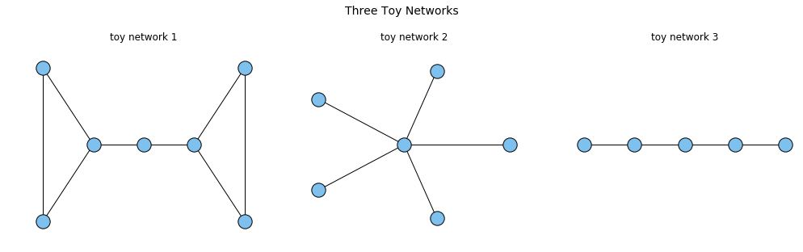

```python
toy1 = nx.disjoint_union(nx.cycle_graph(3), nx.cycle_graph(3))
toy1.add_edges_from([[6,0],[6,3]])
toy1.graph['pos'] = {0:(1,0), 1:(0,1), 2:(0,-1), 3:(3,0), 4:(4,1), 5:(4,-1), 6:(2,0)}
toy2 = nx.Graph(nx.star_graph(5))
toy2.graph['pos'] = nx.shell_layout(toy2, [[0],[1,2,3,4,5]])
toy3 = nx.Graph(nx.path_graph(5), pos=dict((n,(n,0)) for n in range(5)))
toys = [toy1, toy2, toy3]

def draw_toys(centrality_measure, title):
    fig, ax = plt.subplots(1, 3, figsize=(5*(3+.2*2),4))
    plt.subplots_adjust(wspace=.2)
    for i,toy in enumerate(toys):
        if centrality_measure == None:
            nx.draw(toy, pos=toy.graph['pos'], ax=ax[i], node_color='#7ec0ee', edgecolors='k')
        else:
            centralities = centrality_measure(toy) # dictionary
            labels = dict((n,'0' if k<1e-6 else '{:.2g}'.format(k).lstrip('0')) for n,k in centralities.items())
            nx.draw_networkx_labels(toy, pos=toy.graph['pos'],
                                    ax=ax[i], labels=labels, font_size=12)
            nx.draw(toy, pos=toy.graph['pos'], ax=ax[i],
                    node_size=[c*1700+300 for c in centralities.values()],
                    node_color='#7ec0ee', edgecolors='k')
        ax[i].set_title('toy network {}\n'.format(i+1))
    fig.suptitle(title, y=1.1, size=14)

draw_toys(None, 'Three Toy Networks')
```

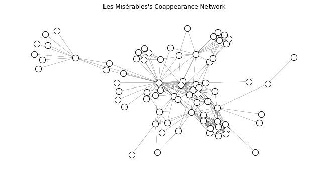

```python
lesmis = nx.read_gml('lesmis/lesmis.gml')
lesmis = nx.convert_node_labels_to_integers(lesmis, label_attribute='name')
lesmis.graph['pos'] = nx.spring_layout(lesmis, seed=5056)

def draw_lesmis(centrality_measure, **kwargs):
    plt.figure(figsize=(8,4))
    if centrality_measure == None:
        nx.draw(lesmis, pos=lesmis.graph['pos'], node_color='w',
                node_size=150, edgecolors='k', width=.25)
    else:
        node_color = list(centrality_measure(lesmis).values())
        from matplotlib import cm, colors
        cmap = colors.LinearSegmentedColormap.from_list('', ['w','r'])
        vmin = kwargs['vmin'] if 'vmin' in kwargs else min(node_color)
        vmax = kwargs['vmax'] if 'vmax' in kwargs else max(node_color)
        norm = colors.Normalize(vmin=vmin, vmax=vmax)
        smap = cm.ScalarMappable(norm, cmap)
        smap.set_array([])
        nx.draw(lesmis, pos=lesmis.graph['pos'],
                node_size=150, edgecolors='k', width=.25,
                node_color=node_color, cmap=cmap, vmin=vmin, vmax=vmax)
        plt.colorbar(smap, pad=.01, aspect=50, label=kwargs.get('label'))
    plt.title('Les Misérables\'s Coappearance Network'+'\n')

draw_lesmis(None)
```

# 1. Degree

While degree returns a dictionary-like object (DegreeView) of degree $k$, degree_centrality returns a dictionary of normalized degree $\hat{k}$.

\begin{align} \hat{k} = \frac{k}{N-1} \end{align}

```python
print('Degree: {}'.format(toy1.degree))
print('Degree: {}'.format(nx.degree(toy1))) # both ways work
print('Normalized degree: {}'.format(nx.degree_centrality(toy1)))
```

```
Degree: [(0, 3), (1, 2), (2, 2), (3, 3), (4, 2), (5, 2), (6, 2)]
Degree: [(0, 3), (1, 2), (2, 2), (3, 3), (4, 2), (5, 2), (6, 2)]
Normalized degree: {0: 0.5, 1: 0.3333333333333333, 2: 0.3333333333333333, 3: 0.5, 4: 0.3333333333333333, 5: 0.3333333333333333, 6: 0.3333333333333333}
```

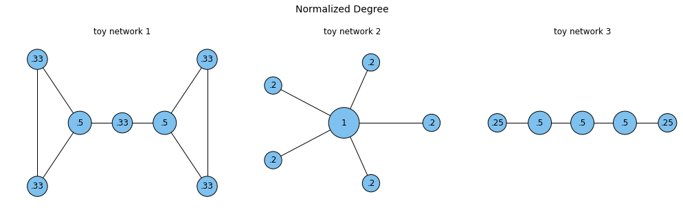

```python
draw_toys(nx.degree_centrality, 'Normalized Degree')
```

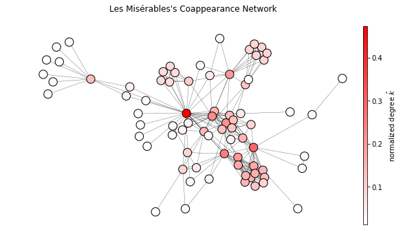

```python
draw_lesmis(nx.degree_centrality,
            label=r'normalized degree $\hat{k}$')
```

# 2. Betweenness

You can get a node's normalized betweenness $\hat{b}$ with betweenness_centrality. You can set normalized=False to get the ordinary betweenness $b$. You can also set endpoints=True to include endpoints while counting the geodesics.

\begin{align} b &= \begin{cases} \sum\limits_{s<t}^{s\neq\,i\neq\,t}{\dfrac{g_{st}{(i)}}{g_{st}}} & \text{(excluding endpoints)} \\ \sum\limits_{s<t}{\dfrac{g_{st}{(i)}}{g_{st}}} & \text{(including endpoints)} \end{cases} \\ \Rightarrow \hat{b} &= \begin{cases} \dfrac{2b}{\left(N-1\right)\left(N-2\right)} & \text{(excluding endpoints)} \\ \dfrac{2b}{N\left(N-1\right)} & \text{(including endpoints)} \end{cases} \end{align}

```python
print('Normalized betweenness: {}'.format(nx.betweenness_centrality(toy1))) # normalized=True, endpoints=False
print('Betweenness: {}'.format(nx.betweenness_centrality(toy1, normalized=False)))
print('Betweenness including endpoints: {}'.format(nx.betweenness_centrality(toy1, normalized=False, endpoints=True)))
```

```
Normalized betweenness: {0: 0.5333333333333333, 1: 0.0, 2: 0.0, 3: 0.5333333333333333, 4: 0.0, 5: 0.0, 6: 0.6}
Betweenness: {0: 8.0, 1: 0.0, 2: 0.0, 3: 8.0, 4: 0.0, 5: 0.0, 6: 9.0}
Betweenness including endpoints: {0: 14.0, 1: 6.0, 2: 6.0, 3: 14.0, 4: 6.0, 5: 6.0, 6: 15.0}
```

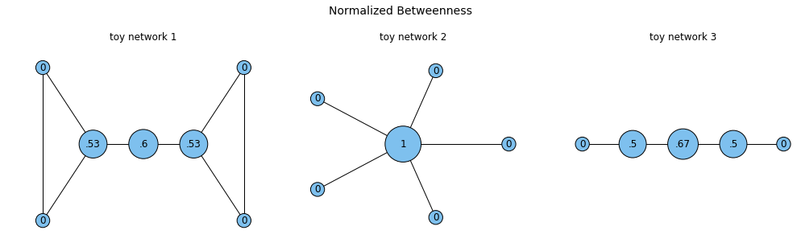

```python
draw_toys(nx.betweenness_centrality, 'Normalized Betweenness')
```

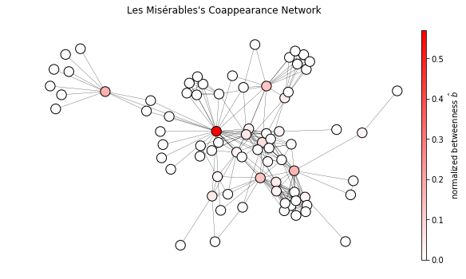

```python
draw_lesmis(nx.betweenness_centrality,
            label=r'normalized betweenness $\hat{b}$')
```

The random walk betweenness $r$ is a conceptually novel alternative to the geodesic betweenness $b$. You can compute it with current_flow_betweenness_centrality, which returns the normalized version $\hat{r}$ by default. The "current" in the method's name refers to electrical current as [the random walk beteweenness is defined with circuit theory](http://aris.ss.uci.edu/~lin/57.pdf).

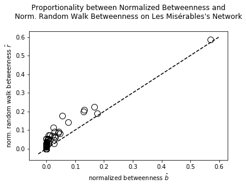

```python
plt.plot(nx.betweenness_centrality(lesmis).values(),
           nx.current_flow_betweenness_centrality(lesmis).values(), 'ko', markerfacecolor='none', markersize=10)
plt.plot(plt.xlim(), plt.xlim(), 'k--')
plt.xlabel(r'normalized betweenness $\hat{b}$')
plt.ylabel(r'norm. random walk betweenness $\hat{r}$')
plt.title('Proportionality between Normalized Betweenness and\n'+
          'Norm. Random Walk Betweenness on Les Misérables\'s Network\n')
plt.show()
```

Precisely, a node's random walk betweenness is $r_i = \sum_{s<t}{I_i^{st}}$, and the "current" from $s$ to $t$ via $i$ is

\begin{align} I_i^{st} = \begin{cases} \delta & (s=i\text{ or }t=i)\\ \dfrac{1}{2}\sum\limits_j{A_{ij}}\left(\Gamma_{is}-\Gamma_{it}-\Gamma_{js}+\Gamma_{jt}\right) & \text{(otherwise)} \end{cases}\, \end{align}

for $\left(\Gamma_{ij}\right)\equiv\mathbf{\Gamma} = (\mathbf{D}-\mathbf{A}+\mathbf{1})^{-1}$, in which $\mathbf{D}$ is the degree matrix and $\mathbf{1}$ a matrix of ones. The value of $\delta$ depends on if the endpoints are included: $\delta = \begin{cases} 0 & \text{(excluding endpoints)} \\ 1 & \text{(including endpoints)} \end{cases}$, while NetworkX's method always exludes the endpoints. The quantity may be normazlied as $\hat{r}$ by multiplying $r$ with $\dfrac{1}{\left(N-1+\delta\right)\left(N-2+\delta\right)}$.

# 3. Closeness

You can compute a node's normalized closeness $\hat{c}$ with closeness_centrality.

\begin{align} c_i = \dfrac{1}{\sum_{j\neq\,i}d_{ij}} \Rightarrow \hat{c} \equiv \dfrac{1}{\bigg({\dfrac{\sum_{j\neq\,i}d_{ij}}{N-1}}\bigg)} = \dfrac{N-1}{\sum_{j\neq\,i}d_{ij}} \end{align}

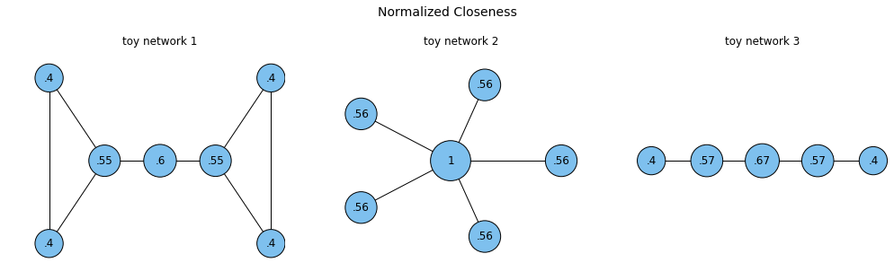

```python
draw_toys(nx.closeness_centrality, 'Normalized Closeness')
```

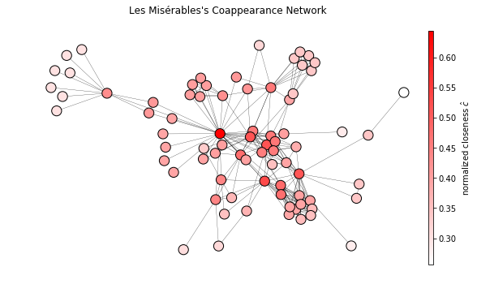

```python
draw_lesmis(nx.closeness_centrality,
            label=r'normalized closeness $\hat{c}$')
```

A closely related quantity is the harmonic centarlity $h$, which reverses the order of the reciprocal and the summation in the ordinary closeness $c$. You can compute it with harmonic_centrality, which returns $h$ instead of its normalized counterpart $\hat{h}$.

\begin{align} h_i = \sum_{j\neq\,i}\dfrac{1}{d{\left(i,j\right)}} \Rightarrow \hat{h} = \dfrac{1}{N-1}\sum_{j\neq\,i}\dfrac{1}{d{\left(i,j\right)}} \end{align}

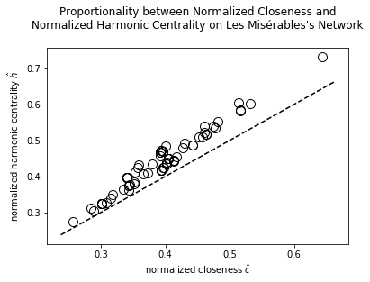

```python
N_lesmis = lesmis.number_of_nodes()

plt.plot(nx.closeness_centrality(lesmis).values(),
         [h/(N_lesmis-1) for h in nx.harmonic_centrality(lesmis).values()],
         'ko', markerfacecolor='none', markersize=10)
plt.plot(plt.xlim(), plt.xlim(), 'k--')
plt.xlabel(r'normalized closeness $\hat{c}$')
plt.ylabel(r'normalized harmonic centrality $\hat{h}$')
plt.title('Proportionality between Normalized Closeness and\n'+
          'Normalized Harmonic Centrality on Les Misérables\'s Network\n')
plt.show()
```

Another interesting closeness-like centrality measures is the information centrality $\eta$, which current_flow_closeness_centrality computes. As the method's name suggests, [the measure is also related to circuit theory](https://www.sciencedirect.com/science/article/abs/pii/0378873389900166?via%3Dihub).

\begin{align} \eta_\text{summation-first} = \dfrac{1}{\sum_{j\neq\,i}{\Omega_{ij}}} &\Rightarrow \hat{\eta} = \left(N-1\right)\eta \\ \eta_\text{reciprocal-first} = \sum_{j\neq\,i}{\dfrac{1}{\Omega_{ij}}} &\Rightarrow \hat{\eta} = \dfrac{\eta}{N-1} \end{align}

Here $\Omega_{ij}$ denotes the so-called [resistance distance](https://en.wikipedia.org/wiki/Resistance_distance), i.e. the equivalent resistance between $i$ and $j$ if every edge carries one ohm.

\begin{align} \Omega_{ij} &= \Gamma_{ii} + \Gamma_{jj} - 2\Gamma_{ij} \text{ for } \\ \left(\Gamma_{ij}\right) &= \mathbf{\Gamma} = (\mathbf{D}-\mathbf{A}+\mathbf{1})^{-1} \end{align}

NetworkX's method returns the non-normalized summation-first form.

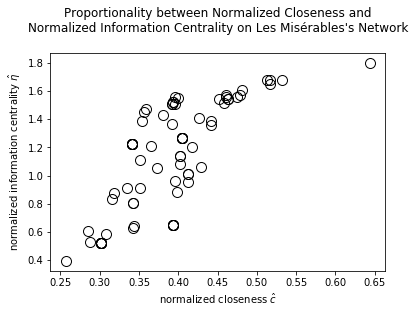

```python
plt.plot(nx.closeness_centrality(lesmis).values(),
         [e*(N_lesmis-1) for e in nx.current_flow_closeness_centrality(lesmis).values()],
         'ko', markerfacecolor='none', markersize=10)
plt.xlabel(r'normalized closeness $\hat{c}$')
plt.ylabel(r'normalized information centrality $\hat{\eta}$')
plt.title('Proportionality between Normalized Closeness and\n'+
          'Normalized Information Centrality on Les Misérables\'s Network\n')
plt.show()
```

# 4. Centralization

A network's centralization quantitifies how much an arbitrary node's centrality differs from those of others and thus how wide a centrality score spreads among nodes. A centralized network has a significant centre; still, the meaning of "centre" depends on the centrality that you are using.

You can measure a netowrk's centralization with various statistical methods, the simplest of which is a centrality's standard deviation. If a centrality has a low standard deviation, all nodes are similar to each other with respect to the index, so the network does not have a prominent centre. The higher a centrality's standard deviation is, the more centralized a network is with respect to it.

```python
print('SD of{0:>10}{1:>10}{2:>10}'.format('degree', 'between', 'close'))
print('='*35)
for i,toy in enumerate(toys):
    print('Toy {0}{1:>10.3f}{2:>10.3f}{3:>10.3f}'.\
          format(i+1, np.std(list(nx.degree_centrality(toy).values())),
                      np.std(list(nx.betweenness_centrality(toy).values())),
                      np.std(list(nx.closeness_centrality(toy).values()))))
```

```
SD of    degree   between     close
===================================
Toy 1     0.075     0.276     0.083
Toy 2     0.298     0.373     0.166
Toy 3     0.122     0.279     0.105
```

Although the standard deviation of a set of normalized data is bound between $0$ and $1$, the upper limit is hardly meaningful as it only occurs when the dataset impossibly consists of $1$'s but has a mean equal to $0$. The lack of a true upper limit could make it hard to interpret the size of standard deviation. Therefore instead of standard deviation, you may want to measure a network's centralization with Freeman centralization and Gini coefficient, which can be better interpreted.

# 4.1 Freeman centralization

If the maximum of a centrality measure $m$ on an $N$-node network is $m^*=\max_i{m_i}$, the network's Freeman centralization score with respect to the measure is

\begin{align} F=\dfrac{\sum_i{\left(m^*-m_i\right)}} {\max{\sum_i{\left(m^*-m_i\right)}}}\,, \end{align}

where the $\text{max}$ runs through the $2^N$ possible $N$-node networks. A more centralized network with respect to a centrality measure has a higher corresponding Freeman centralization score, which is capped at $1$.

Although the denominator is generally intractable, [Freeman proves that](https://www.sciencedirect.com/science/article/abs/pii/0378873378900217?via%3Dihub) it equals $\left(N-1\right)\left(N-2\right)$ for degree $k$, $\frac{1}{2}\left(N-1\right)^2\left(N-2\right)$ for betweenness $b$, and $\dfrac{\left(N-1\right)\left(N-2\right)}{2N-3}$ for normalized closeness $\hat{c}$. Therefore, their corresponding Freeman centralization scores are \begin{align} F_k &= \dfrac{\sum_i{\left(k^*-k_i\right)}} {\left(N-1\right)\left(N-2\right)}\,, \\ F_b &= \dfrac{2 \sum_i{\left(b^*-b_i\right)}} {\left(N-1\right)^2\left(N-2\right)}\,,\text{and} \\ F_\hat{c} &= \dfrac{\left(2N-3\right) \sum_i{\left(\hat{c}^*-\hat{c}_i\right)}} {\left(N-1\right)\left(N-2\right)}\,. \end{align}

```python
def freeman_centralization(G, centrality_measure):
    N = G.number_of_nodes()
    if centrality_measure == 'degree':
        degrees = np.array([k for n,k in G.degree])
        return (degrees.max()-degrees).sum()/((N-1)*(N-2))
    if centrality_measure == 'betweenness':
        betweens = np.array([b for b in nx.betweenness_centrality(G, normalized=False).values()])
        return (betweens.max()-betweens).sum()/((N-1)**2*(N-2)/2)
    if centrality_measure == 'closeness':
        closes = np.array([c for c in nx.closeness_centrality(G).values()])
        return (closes.max()-closes).sum()/((N-1)*(N-2)/(2*N-3))

print('Freeman {0:>7}{1:>10}{2:>10}'.format('degree', 'between', 'close'))
print('='*35)
for i,toy in enumerate(toys):
    print('Toy {0}{1:>10.3f}{2:>10.3f}{3:>10.3f}'.\
          format(i+1, freeman_centralization(toy, 'degree'),
                      freeman_centralization(toy, 'betweenness'),
                      freeman_centralization(toy, 'closeness')))
```

```
Freeman  degree   between     close
===================================
Toy 1     0.167     0.422     0.333
Toy 2     1.000     1.000     1.000
Toy 3     0.167     0.417     0.422
```

## 4.2 Gini coefficient

Alternatively, Gini coefficient is a general statistical tool that measures the inequality of a distribution. An even distribution has a Gini coefficient $G=0$, whereas a completely uneven distribution has $G=1$. The Gini coefficient of an $N$-element set of values $\left\{x\right\}$ is

\begin{align} G = \dfrac{\sum_i\sum_j\lvert{x_i-x_j}\rvert}{2N\sum_i{x_i}}\,. \end{align}

In terms of network science, a centrality measure's high Gini coefficient marks the presence of a significant centre, so the network in question is centralized.

```python
def gini_coefficient(G, centrality_measure):
    N = G.number_of_nodes()
    centralities = [x for x in centrality_measure(G).values()]
    centMatrix = np.repeat([centralities], N, axis=0)
    return (np.abs(centMatrix-centMatrix.T)).sum()/(2*N*sum(centralities))

print('Gini {0:>10}{1:>10}{2:>10}'.format('degree', 'between', 'close'))
print('='*35)
for i,toy in enumerate(toys):
    print('Toy {0}{1:>10.3f}{2:>10.3f}{3:>10.3f}'.\
          format(i+1, gini_coefficient(toy, nx.degree_centrality),
                      gini_coefficient(toy, nx.betweenness_centrality),
                      gini_coefficient(toy, nx.closeness_centrality)))
```

```
Gini     degree   between     close
===================================
Toy 1     0.089     0.583     0.090
Toy 2     0.333     0.833     0.098
Toy 3     0.150     0.440     0.108
```

# 5. Eigenvector centrality

You can compute a node's eigenvector centrality $\varepsilon$ with two methods: eigenvector_centrality or eigenvector_centrality_numpy. The former uses an iterative algorithm of complexity $O\left(E\right)$, whereas the latter directly solves the eigenvector equation, which costs $O\left(N^2\right)$. Therefore, sparse networks usually favour eigenvector_centrality.

\begin{align} \varepsilon_i^{\left(t\right)} &\sim \sum_j{A_{ij}\varepsilon_j^{\left(t-1\right)}} \\ \Rightarrow \vec{\varepsilon} &= \dfrac{1}{\lambda}\mathbf{A}\vec{\varepsilon} \end{align}

The proportionality constant $\lambda$ is chosen to be the largest eigenvalue of $\mathbf{A}$, which invokes [the Perron-Frobenius theorem](https://en.wikipedia.org/wiki/Perron%E2%80%93Frobenius_theorem) and ensures that $\varepsilon\geq0$.

```python
print(nx.eigenvector_centrality(toy1))
print(nx.eigenvector_centrality_numpy(toy1))
```

```
{0: 0.4496173943120344, 1: 0.3348059077247064, 2: 0.3348059077247064, 3: 0.4496173943120344, 4: 0.3348059077247064, 5: 0.3348059077247064, 6: 0.3838077827176706}
{0: 0.44961772968980884, 1: 0.33480527325511306, 2: 0.334805273255113, 3: 0.4496177296898077, 4: 0.334805273255112, 5: 0.334805273255112, 6: 0.38380921080589353}
```

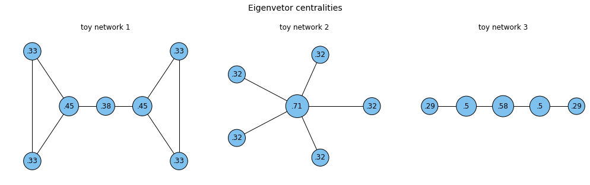

```python
draw_toys(nx.eigenvector_centrality, 'Eigenvetor centralities')
```

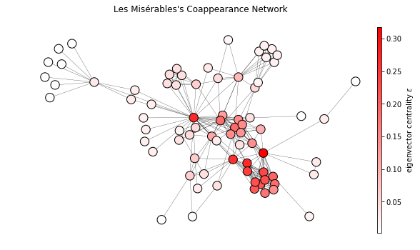

```python
draw_lesmis(nx.eigenvector_centrality,
            label=r'eigenvector centrality $\varepsilon$')
```

Katz centrality $\chi$ is a closely related centrality measure. Similarly, you can also compute it with an iterative algorithm, i.e. katz_centrality, or by solving an eigenvector equation, i.e. katz_centrality_numpy.

\begin{align} \chi_i^{\left(t\right)} &= \alpha\sum_j{A_{ij}\chi_j^{\left(t-1\right)}}+\beta_i \\ \Rightarrow \vec{\chi} &= \left(\mathbf{I}-\alpha\mathbf{A}\right)^{-1}\vec{\beta} \end{align}

Note that Katz centrality coincides with eigenvector centrality if $\alpha\rightarrow\lambda^{-1}$ and $\beta_i=1\forall i$.

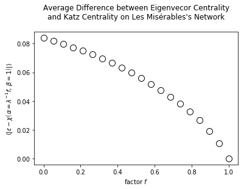

```python
def compare_katz_and_eigen(G, factor):
    N = G.number_of_nodes()
    eig = nx.eigenvector_centrality(G)
    eigval_max = np.linalg.eigvalsh(nx.to_numpy_array(G)).max()
    katz = nx.katz_centrality_numpy(G, alpha=eigval_max**-1*factor, beta=1)
    return sum([abs(katz[i]-eig[i]) for i in G.nodes])/N

factor = np.linspace(0,1,20)
plt.plot(factor, [compare_katz_and_eigen(lesmis, f) for f in factor],
         'ko', markerfacecolor='none', markersize=10)
plt.xlabel(r'factor $f$')
plt.ylabel(r'$\langle|\varepsilon-\chi\left(\alpha=\lambda^{-1}f,\,\beta=1\right)|\rangle$')
plt.title('Average Difference between Eigenvecor Centrality\nand Katz Centrality on Les Misérables\'s Network\n')
plt.show()
```

# 6. Link Analysis

So far we have been only focusing on centrality measures on undirected networks, while many real networks like the Internet are directed. In addition to conventional measures, viz. degree, betweenness, and closeness, we need a more devoted approach to diagnose each link's quality and thus quantify each node's importance on directed networks. Here I will introduce two tools: Google's PageRank and HITS algorithm.

To avoid confusion, here I define $A_{ij}=1$ as the presence of link **from $j$ to $i$**.

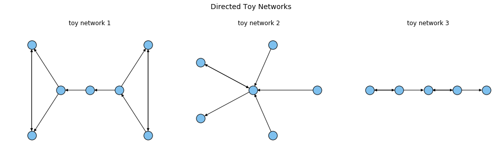

```python
np.random.seed(5056)
toys_directed = []
for toy in toys:
    toyD = toy.to_directed()
    actions = np.random.choice(3, size=toyD.number_of_edges())
    for (u,v),a in zip(toy.edges, actions):
        if a==0:
            toyD.remove_edge(u,v)
        elif a==1:
            toyD.remove_edge(v,u)
    toys_directed += [toyD]

def draw_toys_directed(centrality_measure, title):
    fig, ax = plt.subplots(1, 3, figsize=(5*(3+.2*2),4))
    plt.subplots_adjust(wspace=.2)
    for i,toy in enumerate(toys_directed):
        if centrality_measure == None:
            nx.draw(toy, pos=toy.graph['pos'], ax=ax[i], node_color='#7ec0ee', edgecolors='k')
        else:
            centralities = centrality_measure(toy) # dictionary
            labels = dict((n,'0' if k<1e-6 else '{:.2g}'.format(k).lstrip('0')) for n,k in centralities.items())
            nx.draw_networkx_labels(toy, pos=toy.graph['pos'],
                                    ax=ax[i], labels=labels, font_size=12)
            nx.draw(toy, pos=toy.graph['pos'], ax=ax[i],
                    node_size=[c*1700+300 for c in centralities.values()],
                    node_color='#7ec0ee', edgecolors='k')
        ax[i].set_title('toy network {}\n'.format(i+1))
    fig.suptitle(title, y=1.1, size=14)

draw_toys_directed(None, 'Directed Toy Networks')
```

## 6.1 PageRank

PageRank is the webpage-sorting algorithm of Google, where "Page" in the algorithm's name refers to its inventor Larry Page instead of webpages. It is a variant of eigenvector centrality and Katz centrality; a node's PageRank $\pi$ satisfies

\begin{align} \pi_i^{\left(t\right)} &= \alpha\sum_j{\dfrac{A_{ij}}{k^\text{out}_j}\pi_j^{\left(t-1\right)}}+\beta_i \\ \Rightarrow \vec{\pi} &= \left(\mathbf{I}-\alpha\mathbf{A}\mathbf{D}_\text{out}^{-1}\right)^{-1}\vec{\beta}\,. \end{align}

Here are three reminders.

1. Conventionally $\beta_i$ is set as $\dfrac{1-\alpha}{N}$ so that all nodes' PageRank scores sum up to $1$. NetworkX enforces this constraint unless you provide a heterogenous $\vec{\beta}$, which is set with the attribute personalization.
2. The damping factor $\alpha\in\left[0,1\right]$ describes how probably a surfer clicks on the hyperlinks on webpages. A surfer with $\alpha=0$ browse in a completely random manner, so all nodes have a PageRank score equal to $\dfrac{1}{N}$.
3. If node $j$ does not have any out-links, i.e. $k_j^\text{out}=0$, it is assumed to link to all nodes including itself, i.e. $k_j^\text{out}$ becomes $N$ and $A_{ij}=1 \forall i$. This means that a surfer randomly jumps to some node after reaching a sink.

You can use pagerank, pagerank_numpy, or pagerank_scipy to compute PageRank. The first method employs an interative algorithm, whereas the others solve the matrix equation.

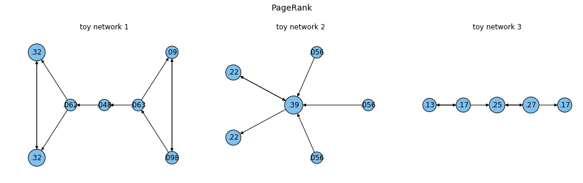

```python
draw_toys_directed(nx.pagerank, 'PageRank')
```

Interestingly, [a node's PageRank score is almost proportional to its degree on an undirected network](https://www.sciencedirect.com/science/article/pii/S0020019015000381?via%3Dihub).

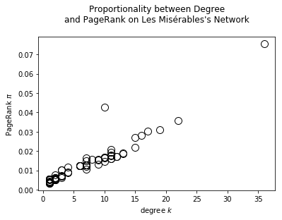

```python
page = list(nx.pagerank(lesmis, alpha=0.85, personalization=None).values())
degs = [k for n,k in lesmis.degree]

plt.plot(degs, page, 'ko', markerfacecolor='none', markersize=10)
plt.xlabel(r'degree $k$')
plt.ylabel(r'PageRank $\pi$')
plt.title('Proportionality between Degree\nand PageRank on Les Misérables\'s Network\n')
plt.show()
```

In addition, google_matrix returns a network's so-called Google matrix

\begin{align} \mathbf{G} = \alpha\mathbf{A}\mathbf{D}_\text{out}^{-1} + \left(\dfrac{1-\alpha}{N}\right)\mathbf{1}\,, \end{align}

which helps rewrite the matrix equations above as

\begin{align} \vec{\pi} = \mathbf{G} \vec{\pi}\,. \end{align}

## 6.2 HITS algorithm

HITS algorithm classifies nodes on a directed network into hubs and authorities: hubs link to authorities. In terms of a citation network, good hubs cite many famous papers, whereas good authorities receive citations from many famous papers. Hence, the nodes' hub scores $h$ and authority scores $a$ satisfy

\begin{align} \begin{cases} a_i^\left({t}\right) \sim \sum_j {A_{ij} h_j^\left({t-1}\right)} \\ h_i^\left({t}\right) \sim \sum_j {A_{ji} a_j^\left({t-1}\right)} \end{cases}\,. \end{align}

The set of equations is equivalent to

\begin{align} \begin{cases} \vec{a} \sim \mathbf{A} \vec{h} \\ \vec{h} \sim \mathbf{A}^\text{T} \vec{a} \end{cases} \Rightarrow \begin{cases} \vec{a} = \lambda_a^{-1} \left(\mathbf{A} \mathbf{A}^\text{T}\right) \vec{a} \\ \vec{h} = \lambda_h^{-1} \left(\mathbf{A}^\text{T} \mathbf{A}\right) \vec{h} \end{cases}\,, \end{align}

where $\lambda_a$ is the largest eigenvalue of $\mathbf{A} \mathbf{A}^\text{T}$ and $\lambda_h$ the one of $\mathbf{A}^\text{T} \mathbf{A}$. Again, you can compute nodes' hub scores and authorities scores with an iterative approach, i.e. hits, or a matrix approach, i.e. hits_numpy and hist_scipy.

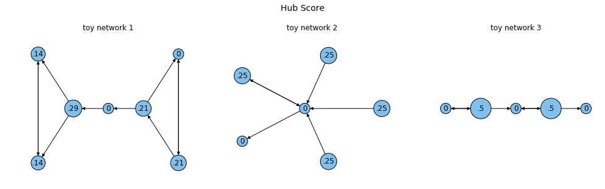

```python
draw_toys_directed(lambda G: nx.hits(G)[0], 'Hub Score')
```

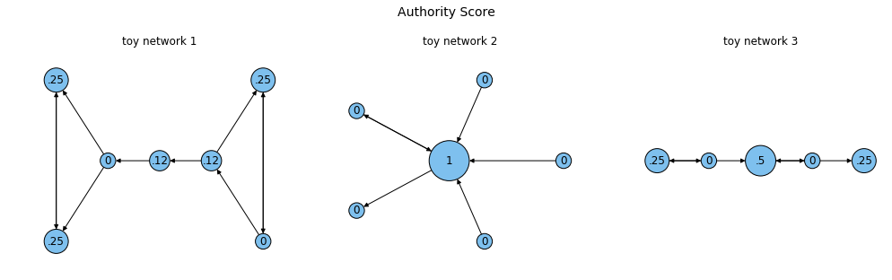

```python
draw_toys_directed(lambda G: nx.hits(G)[1], 'Authority Score')
```

A node's hub score equals its authority score on an undirected network.

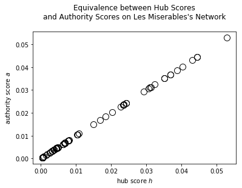

```python
plt.plot(*(ha.values() for ha in nx.hits(lesmis)),
         'ko', markerfacecolor='none', markersize=10)
plt.xlabel(r'hub score $h$')
plt.ylabel(r'authority score $a$')
plt.title('Equivalence between Hub Scores\nand Authority Scores on Les Miserables\'s Network\n')
plt.show()
```

# 7. Cliques and Cores

While the previous centrality measures define centrality with the pairwise relationships betweeen a nodes and others, here we will explore a community-based approach, which quantifies a node's centrality according to the community it belongs to. Intuitively, a person is important if he belongs to an important community. Still, it is challenging to define "community"; two concepts that we will use are cliques and cores.

A $k$-clique is a $k$-node subgraph in which all nodes are connected to each other, and a node's clique nubmer $q$ is the size of the largest clique to which it belongs. You can compute a node's clique number with node_clique_number.

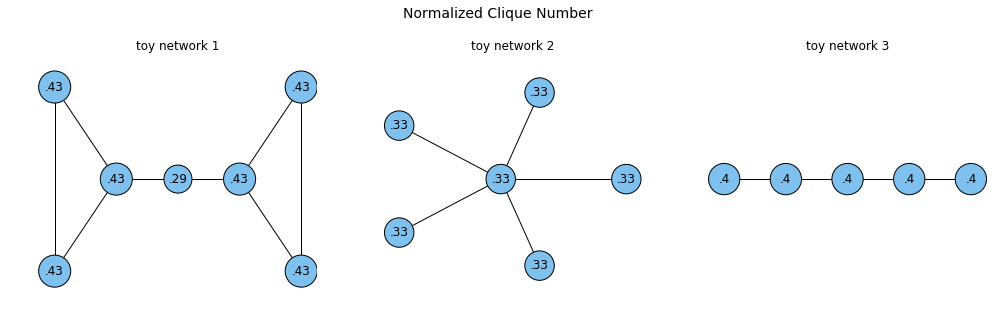

```python
def normalized_clique_number(G):
    N = G.number_of_nodes()
    cliques = nx.node_clique_number(G)
    return dict((key, value/N) for key,value in cliques.items())

draw_toys(normalized_clique_number, 'Normalized Clique Number')
```

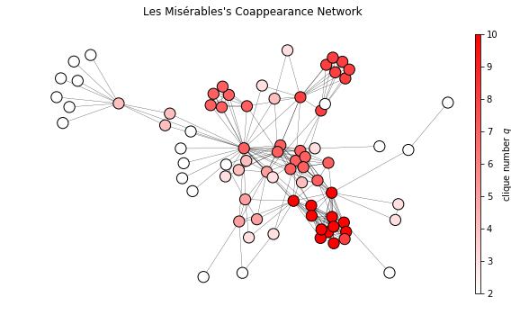

```python
draw_lesmis(nx.node_clique_number, label=r'clique number $q$')
```

However, the complexity of computing a node's clique number grows exponetially with a network's size, so the measure is barely feasible for real-world networks. Instead of clique number, a more practical measure is core number. The $k$-core is the maximal subgraph in which all nodes have a degree at least equal to $k$. A simple algorithm to find the $k$-core runs in the following procedures.

1. Remove all nodes with degrees less than $k$ and their edges.
2. Update the remaining nodes' degrees.
3. Repeat step 1 until the graph only contains nodes with degrees greater than or equal to $k$.

A node's core nubmer $c$ equals the maximum $k$ of all $k$-cores it belongs to. You can compute a node's core number with core_number. A graph's core number is the maximum core number among all of its nodes---what is a tree's core number?

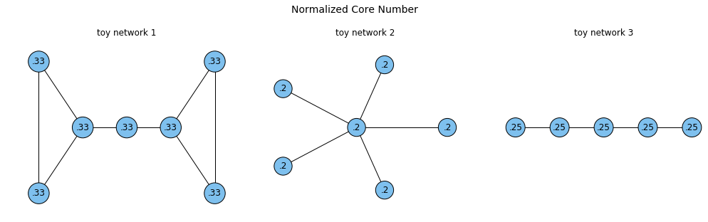

```python
def normalized_core_number(G):
    N = G.number_of_nodes()
    cores = nx.core_number(G)
    return dict((key, value/(N-1)) for key,value in cores.items())

draw_toys(normalized_core_number, 'Normalized Core Number')
```

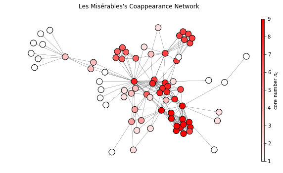

```python
draw_lesmis(nx.core_number, label=r'core number $n_c$')
```

For your interest, shell, crust, and corona are three related but rarely used concepts.

- The $k$-shell is the subgraph in which all nodes have $n_c=k$.
- The $k$-curst is the subgraph in which all nodes have $n_c\leq k$.
- The $k$-corona is the subgraph in which all nodes have $n_c=k$ and $k$ neighbours in the $k$-core.

Hence, a graph can always be decomposed into a $\left(k-1\right)$-crust, a $k$-shell, and a $\left(k+1\right)$-core for all $k\in\mathbb{N}$.

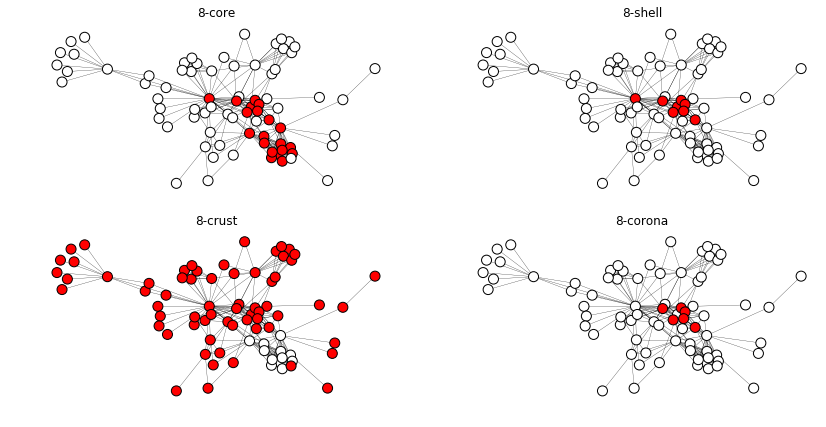

```python
k = 8
fig,ax = plt.subplots(2, 2, figsize=(14,7))
for a,comm in zip(ax.flatten(), ['core', 'shell', 'crust', 'corona']):
    a.set_title('{0}-{1}'.format(k, comm))
    nx.draw(lesmis, pos=lesmis.graph['pos'], ax=a,
            node_color=['r' if i in eval('nx.k_'+comm)(lesmis, k).nodes else 'w' for i in range(N_lesmis)],
            node_size=100, edgecolors='k', width=.25)
```

# 8. Similarity

Similarity between nodes may also serve as the foundation of centrality. If a node is similar to many nodes, the node is ordinary and has nothing special; on the other hand, if a node is very different from others, the node is likely an extraordinary node and thus a possible centre. There are three kinds of similarity: structural similarity, automorphic similarity, and regular similarity. Here I will illustrate the three concepts in terms of a social network.

- Two people are structurally similar if they share many mutual friends. You and your siblings are structrually very similar because you share many family members and relatives.
- Two people are automorphically similar if they have topologically similar neighbourhoods. We will be (somewhat) automorphically similar if we, for example, know the same number of people in this class and thus possess the same degree.
- Two people are regularly similar if they have connections with similar people. Hence, we are (somewhat) regularly similar because we all know some professors and have some classmates.

In fact, structural similarity implies automorphic similarity, which implies regular similarity. While it is still hard to quantify the automorphic or regular similarity with current network science, here we will go through three measures for structural similarity, viz. cosine similarity, Pearson correlation coefficient, and Euclidean distance.

## 8.1 Cosine similarity

Two nodes' cosine similarity is defined as

\begin{align} \sigma_{ij} = \dfrac{\sum_h{A_{ih}A_{jh}}}{\sqrt{\sum_h{A_{ih}^2}} \sqrt{\sum_h{A_{jh}^2}}} = \dfrac{\sum_h{A_{ih}A_{jh}}}{\sqrt{k_ik_j}}\,. \end{align}

While $\sigma_{ij}=1$ if two nodes have the same neighbours, $\sigma_{ij}=0$ if they share no neighbours at all.

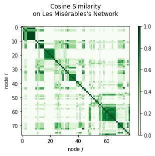

```python
def cosine_similarity(G):
    A = nx.to_numpy_array(G)
    k = A.sum(1).reshape(-1, 1)
    return A@A/np.sqrt(k@k.T)

plt.imshow(cosine_similarity(lesmis),
           cmap='Greens', vmin=0, vmax=1)
plt.xlabel(r'node $j$')
plt.ylabel(r'node $i$')
plt.title('Cosine Similarity\non Les Misérables\'s Network\n')
plt.colorbar(aspect=50)
plt.show()
```

## 8.2 Pearson correlation coefficient

Two nodes' Pearson correlation coefficient is defined as

\begin{align} r_{ij} &= \dfrac{\sum_h \left(A_{ih}-\langle{A_i}\rangle\right) \left(A_{jh}-\langle{A_j}\rangle\right)} {\sqrt{\sum_h \left(A_{ih}-\langle{A_i}\rangle\right)^2} \sqrt{\sum_h \left(A_{jh}-\langle{A_j}\rangle\right)^2}} \\ &= \dfrac{\text{cov}{\left({A_i,A_j}\right)}} {\sqrt{\text{var}{\left(A_i\right)} \text{var}{\left(A_j\right)}}}\,. \end{align}

The coefficient $r_{ij}$ is bounded in $\left[-1,1\right]$ and increases with two nodes' similarity.

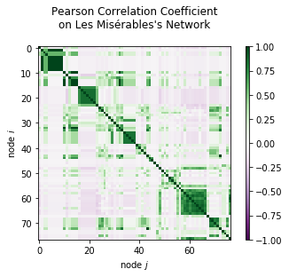

```python
def pearson_correlation_coeffficient(G):
    A = nx.to_numpy_array(G)
    V = A.var(axis=1, ddof=0).reshape(-1, 1)
    return np.cov(A, ddof=0)/np.sqrt(V@V.T)

plt.imshow(pearson_correlation_coeffficient(lesmis),
           cmap='PRGn', vmin=-1, vmax=1)
plt.xlabel(r'node $j$')
plt.ylabel(r'node $i$')
plt.title('Pearson Correlation Coefficient\non Les Misérables\'s Network\n')
plt.colorbar(aspect=50)
plt.show()
```

## 8.3 Euclidean distance

The Euclidean distance between two nodes is defined as

\begin{align} d_{ij} = \dfrac{\sum_h \left(A_{ih}-A_{jh}\right)^2 }{k_i+k_j} = 1-\dfrac{2n_{ij}}{k_i+k_j}\,, \end{align}

where $n_{ij}$ is the number of neighbours that $i$ and $j$ share. Unlike the previous two measure, a greater Euclidean distance implies a more different pair of nodes: $i$ and $j$ are the most similar if $d_{ij}=0$, while they are the most different if $d_{ij}=1$.

Since $A_{ij}$ equals either $0$ or $1$, the Euclidean distance between two nodes' adjacencies is identical to their Hamming distance.

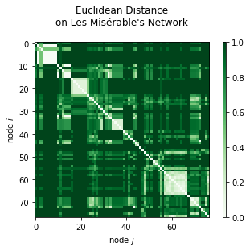

```python
def euclidean_distance(G):
    A = nx.to_numpy_array(G)
    k = np.repeat([A.sum(0)], len(A), 0)
    return 1-2*A@A/(k+k.T)

plt.imshow(euclidean_distance(lesmis),
           cmap='Greens', vmin=0, vmax=1)
plt.xlabel(r'node $j$')
plt.ylabel(r'node $i$')
plt.title('Euclidean Distance\non Les Misérable\'s Network\n')
plt.colorbar(aspect=50)
plt.show()
```